# Keyword trends in aquatic vegetation biology and ecology

Arthur de Grandpré

31/10/2020

# Methods

This script counts word occurrences in titles and abstract of 500 papers from 1990 to 1999, 2000 to 2009, 2010 to 2019 in order to represent trends and research biases. The search was performed on dimensions.ai with the search terms “aquatic vegetation” OR “macrophytes” OR “aquatic plants” OR “seagrass”, within the fields of plant biology AND ecology. The 500 better cited paper according the FCR index were selected for each time period according to the extraction limit from the platform.

The resulting data is structure as follow:

```
## # A tibble: 6 x 7
##   PubYear Title       Abstract       `MeSH terms`      `Times cited`   RCR   FCR
##     <dbl> <chr>       <chr>          <chr>                     <dbl> <dbl> <dbl>
## 1    2006 A Global C~ "Seagrasses, ~ <NA>                       1517 NA    149.
## 2    2001 Biology of~ "Mangroves ar~ <NA>                        781 NA     73.8
## 3    2007 Global sea~ "Seagrasses, ~ <NA>                        467 NA     48.1
## 4    2000 Bacteria i~ "The extremel~ Bacteria; Bacter~           589 10.2   45.4
## 5    2002 Nitrogen i~ "Aquatic ecos~ Animals; Conserv~           476  3.12  40.8
## 6    2007 Seagrasses~ "This review ~ <NA>                        376 NA     38.7
```

Using the tm package for text mining, all words from the titles and abstracts are extracted and stemmed to their shortest general form (plants becomes plant, concentration becomes concentr). They were then all counted, ranked and filtered. Uninteresting words and those part of the original research keywords were removed, and the remaining were put into a word cloud.

The list of custom stopwords included contains is as follow :

c(“plant”,“seagrass”,“aquat”,“macrophyt”,“effect”,  
“respons”,“wetland”,“tropic”,“water”,“speci”,“impact”,  
“influenc”,“two”,“submerg”,“new”,“use”,“increas”,“studi”,  
“differ”,“high”,“low”,“concentr”,“may”,“result”,“veget”,  
“show”,“also”,“can”,“found”,“total”,“limit”,“higher”,  
“reduc”,“level”,“howev”,“suggest”,“affect”,“signific”,  
“within”,“three”,“measur”,“among”,“test”, “lake”,“rate”,“biomass”,“chang”,“relat”,“condit”, “organ”,“growth”,“leav”,“indic”,“import”,“site”,“meadow”))

# Wordclouds

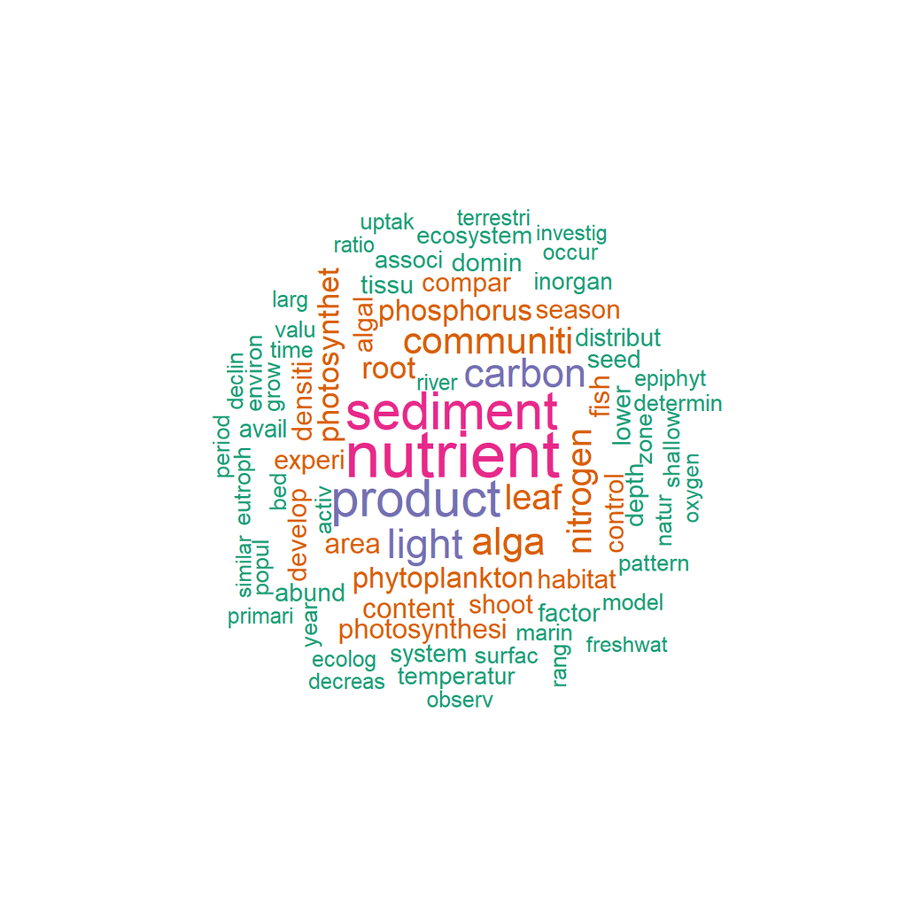

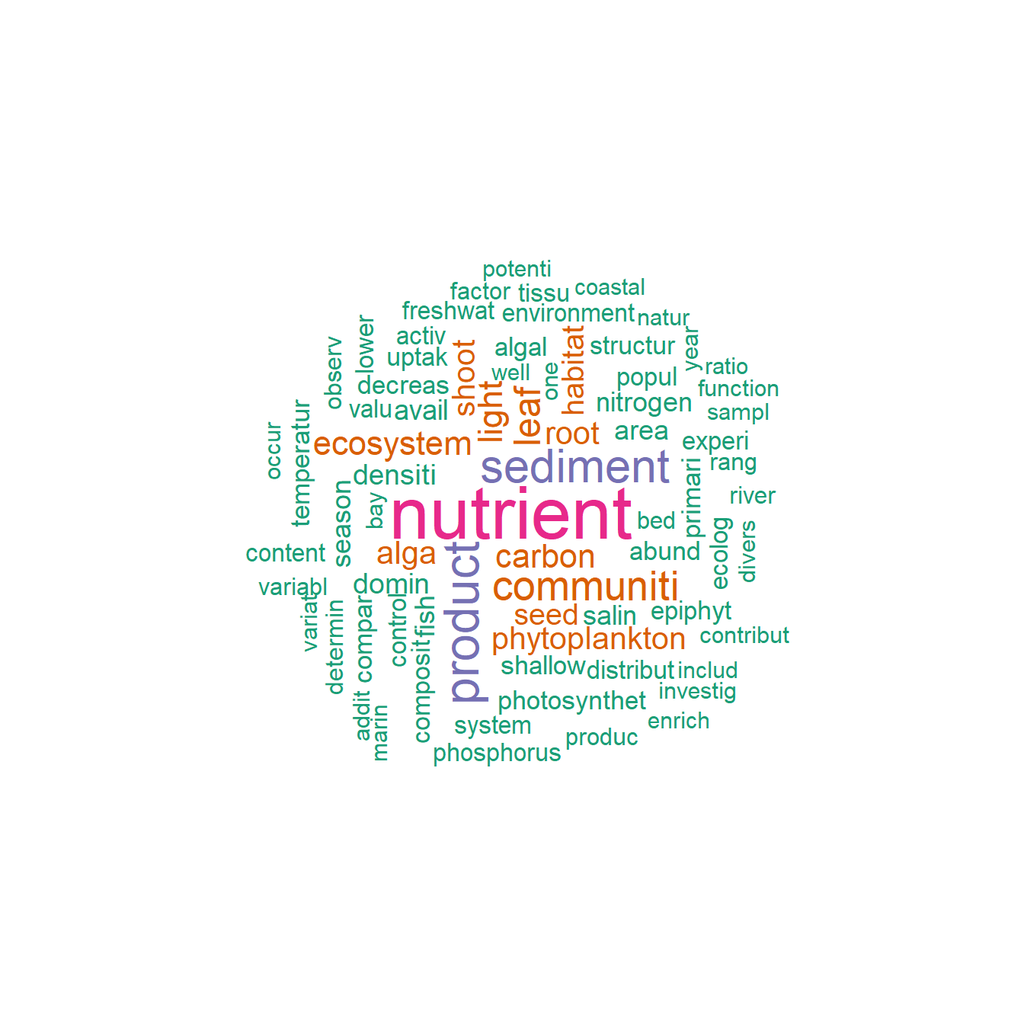

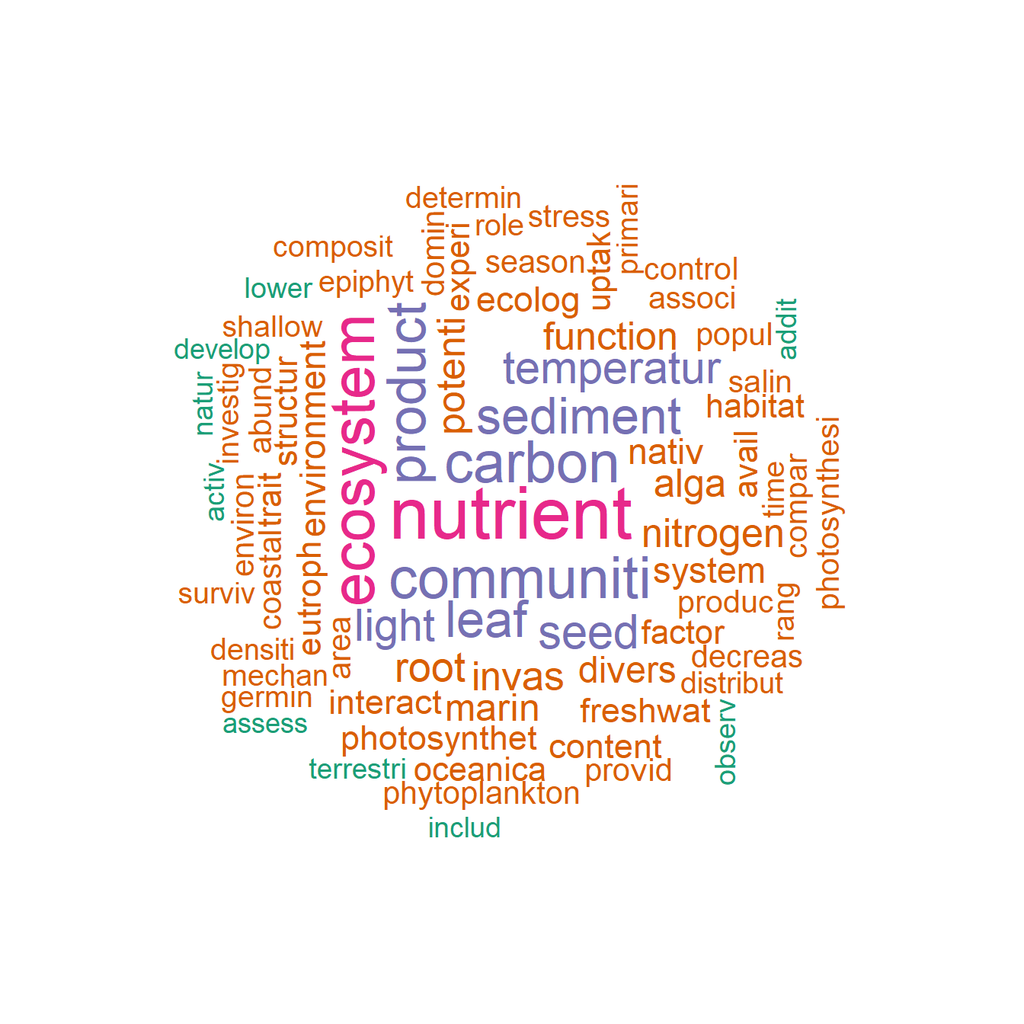

# Barplots

The results can also be displayed as barplots, in a more neutral manner, either combined or by year.  
Let’s try it with 15 words.

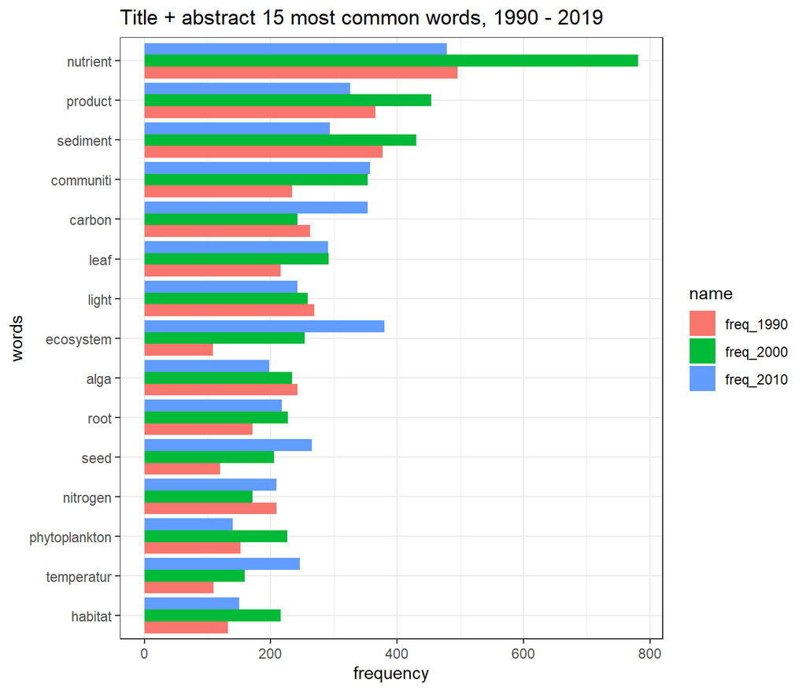

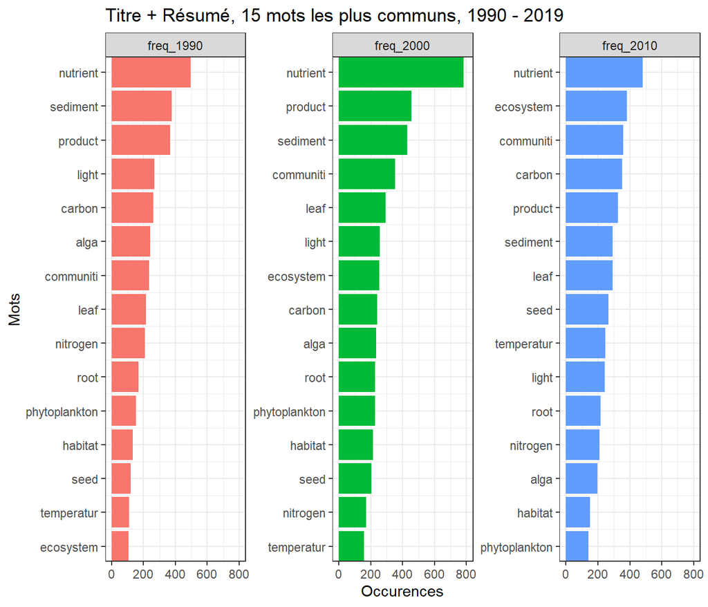

Now with 25 words.

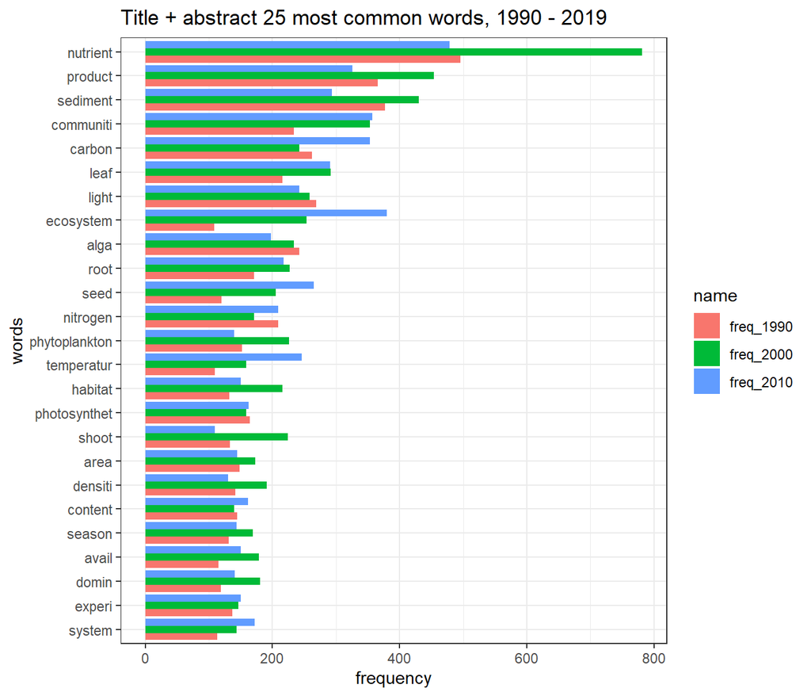

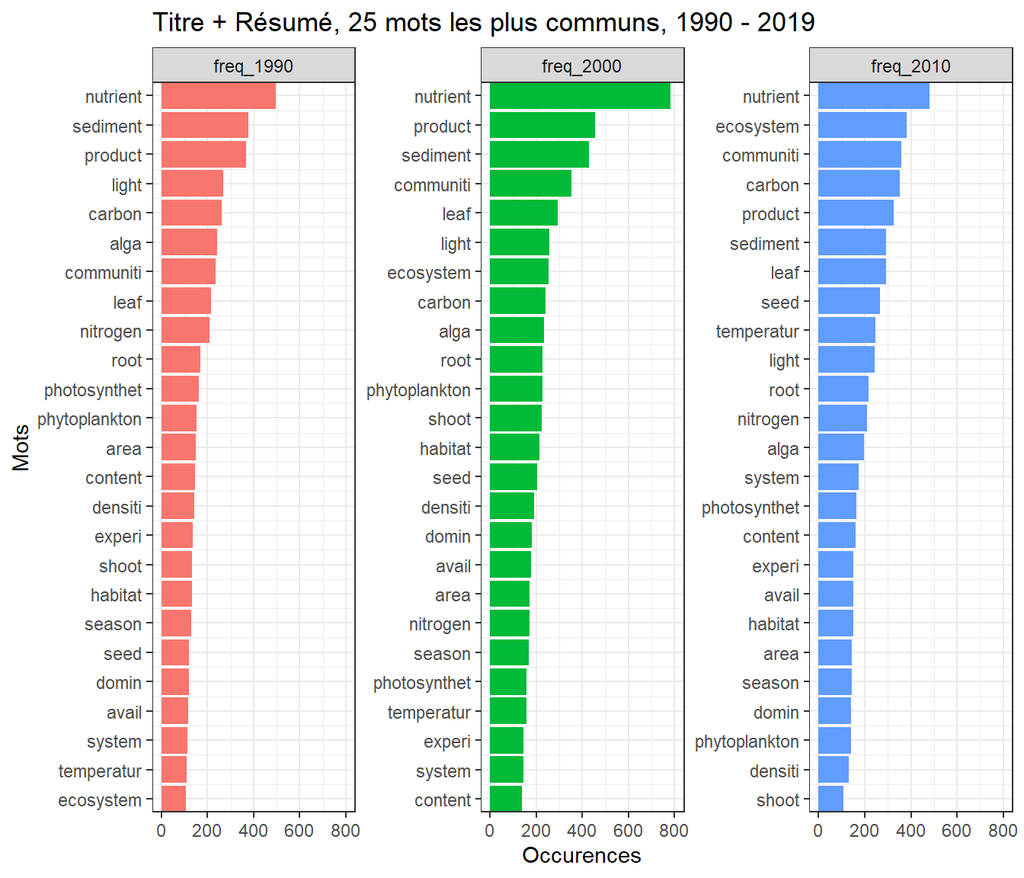